# Análisis de Diabetes tipo 2 con Machine Learning

Este notebook documenta y explica paso a paso el proceso de análisis, preprocesamiento, exploración, modelado y evaluación de un dataset de pacientes para la detección de diabetes tipo 2. Se incluyen los gráficos generados y se explica el propósito de cada parte del código y resultado visual.

**Estructura:**

1. Preprocesamiento de datos
2. Análisis exploratorio y visualización
3. Entrenamiento y evaluación de modelos
4. Interpretación de resultados

## 1. Preprocesamiento de datos

El preprocesamiento es fundamental para asegurar la calidad de los datos antes de entrenar modelos de machine learning. En este proyecto, se realiza lo siguiente:

- Carga del dataset original en formato ARFF.
- Conversión a DataFrame de pandas.
- Imputación de valores inválidos (ceros en variables clínicas) usando la mediana.
- Guardado del dataset limpio en formato CSV.

El siguiente código realiza estas tareas:

```python
import pandas as pd
import numpy as np
from scipy.io import arff

# Cargar el dataset original en formato ARFF
data, meta = arff.loadarff('../data/dataset_37_diabetes.arff')
df = pd.DataFrame(data)

# Convertir bytes a strings si es necesario
def decode_bytes(df):
    for col in df.select_dtypes(include='object').columns:
        df[col] = df[col].apply(lambda x: x.decode('utf-8') if isinstance(x, bytes) else x)
    return df

df = decode_bytes(df)

# Imputar ceros inválidos en variables clínicas con la mediana
columnas_a_imputar = ['plas', 'pres', 'skin', 'insu', 'mass']
for col in columnas_a_imputar:
    df[col] = df[col].replace(0, np.nan)
    mediana = df[col].median()
    df[col] = df[col].fillna(mediana)

# Guardar el dataset limpio (opcional)
df.to_csv('../data/dataset_limpio.csv', index=False)
df.head()
```

|  | preg | plas | pres | skin | insu | mass | pedi | age | class |
| --- | --- | --- | --- | --- | --- | --- | --- | --- | --- |
| 0 | 6.0 | 148.0 | 72.0 | 35.0 | 125.0 | 33.6 | 0.627 | 50.0 | tested_positive |
| 1 | 1.0 | 85.0 | 66.0 | 29.0 | 125.0 | 26.6 | 0.351 | 31.0 | tested_negative |
| 2 | 8.0 | 183.0 | 64.0 | 29.0 | 125.0 | 23.3 | 0.672 | 32.0 | tested_positive |
| 3 | 1.0 | 89.0 | 66.0 | 23.0 | 94.0 | 28.1 | 0.167 | 21.0 | tested_negative |
| 4 | 0.0 | 137.0 | 40.0 | 35.0 | 168.0 | 43.1 | 2.288 | 33.0 | tested_positive |

## 2. Análisis exploratorio y visualización

El análisis exploratorio permite entender la distribución y características de los datos. Se generan histogramas y boxplots para cada variable, lo que ayuda a identificar patrones, valores atípicos y la forma de las distribuciones.

A continuación, se muestran los histogramas y boxplots generados para cada variable:

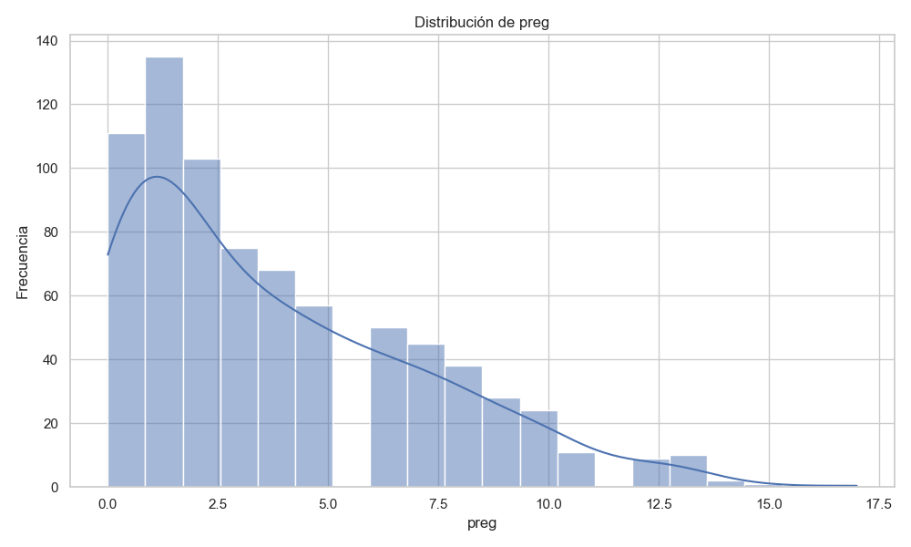

```
Histograma de preg: muestra la distribución de la variable en la población. Permite observar asimetrías, valores frecuentes y posibles outliers.
```

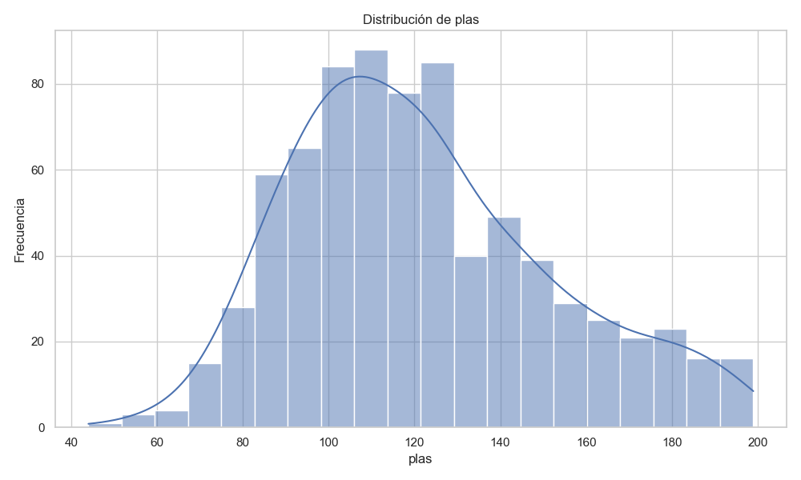

```
Histograma de plas: muestra la distribución de la variable en la población. Permite observar asimetrías, valores frecuentes y posibles outliers.
```

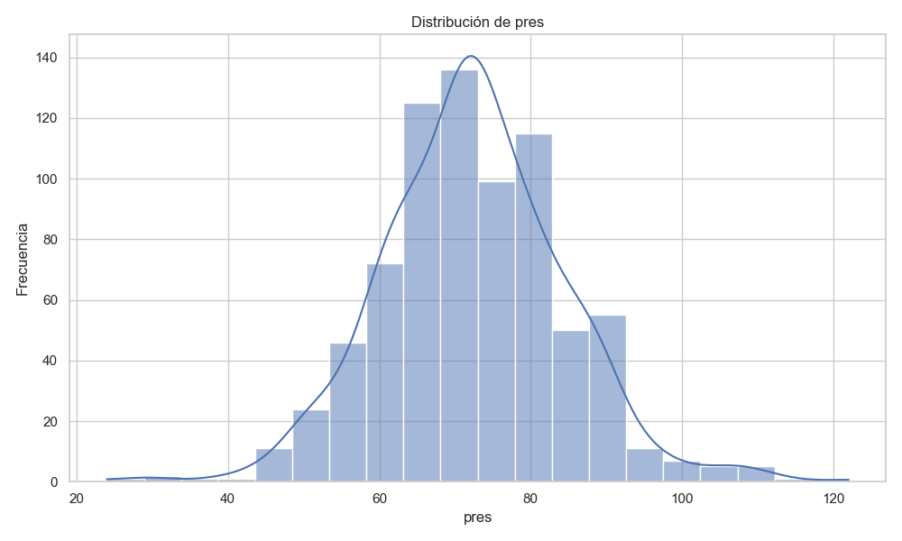

```
Histograma de pres: muestra la distribución de la variable en la población. Permite observar asimetrías, valores frecuentes y posibles outliers.
```

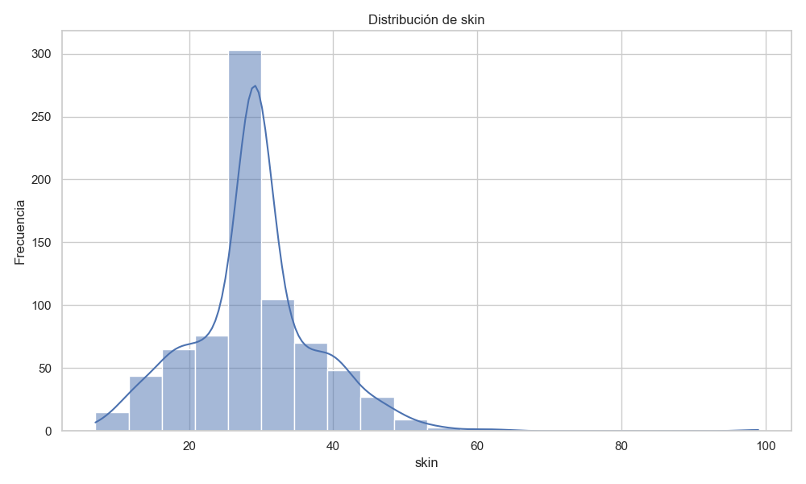

```
Histograma de skin: muestra la distribución de la variable en la población. Permite observar asimetrías, valores frecuentes y posibles outliers.
```

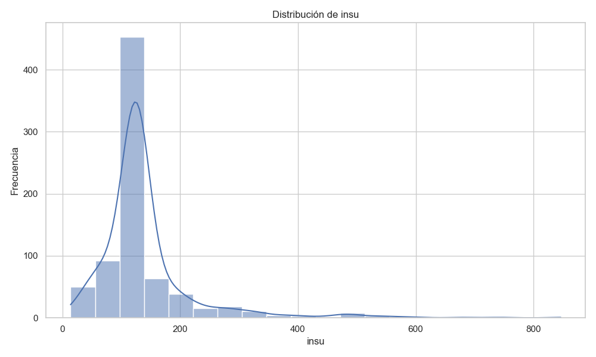

```
Histograma de insu: muestra la distribución de la variable en la población. Permite observar asimetrías, valores frecuentes y posibles outliers.
```

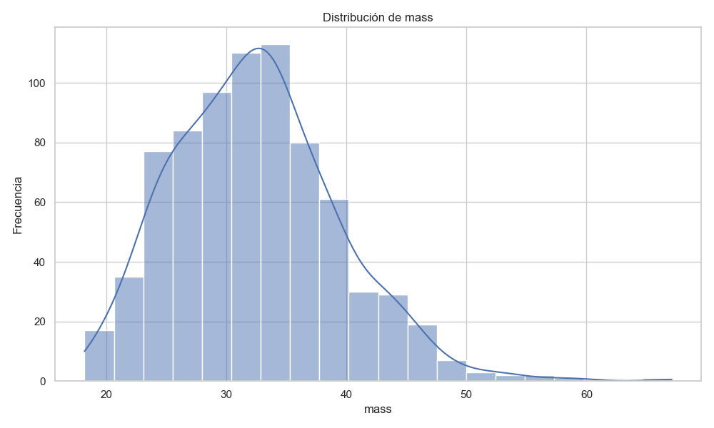

```
Histograma de mass: muestra la distribución de la variable en la población. Permite observar asimetrías, valores frecuentes y posibles outliers.
```

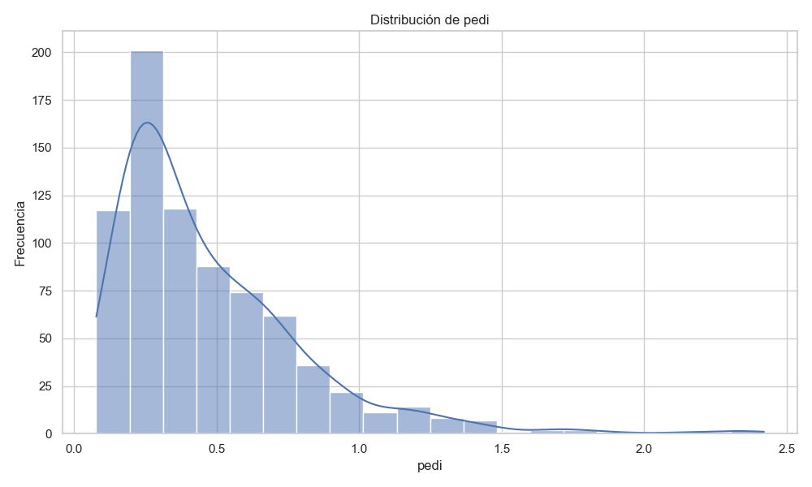

```
Histograma de pedi: muestra la distribución de la variable en la población. Permite observar asimetrías, valores frecuentes y posibles outliers.
```

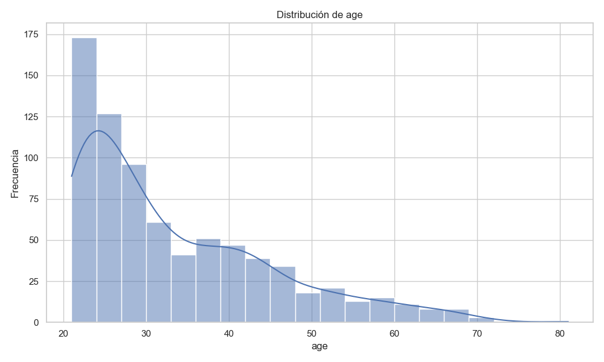

```
Histograma de age: muestra la distribución de la variable en la población. Permite observar asimetrías, valores frecuentes y posibles outliers.
```

```python
import matplotlib.pyplot as plt
from IPython.display import Image, display

# Mostrar histogramas de cada variable
variables = ['preg', 'plas', 'pres', 'skin', 'insu', 'mass', 'pedi', 'age']
for var in variables:
    display(Image(filename=f'../graficos/hist_{var}.png'))
    print(f"Histograma de {var}: muestra la distribución de la variable en la población. Permite observar asimetrías, valores frecuentes y posibles outliers.")
```

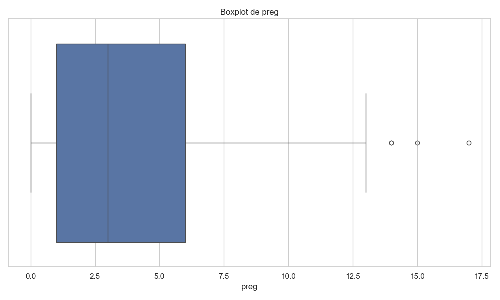

```
Boxplot de preg: permite identificar la mediana, los cuartiles y los valores atípicos de la variable.
```

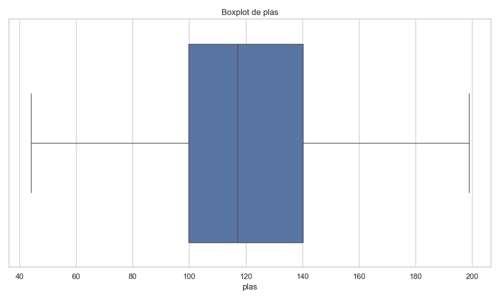

```
Boxplot de plas: permite identificar la mediana, los cuartiles y los valores atípicos de la variable.
```

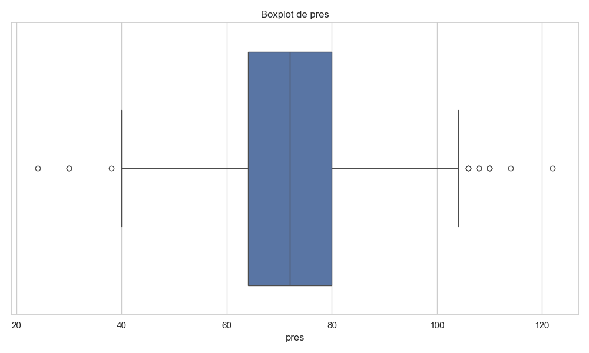

```
Boxplot de pres: permite identificar la mediana, los cuartiles y los valores atípicos de la variable.
```

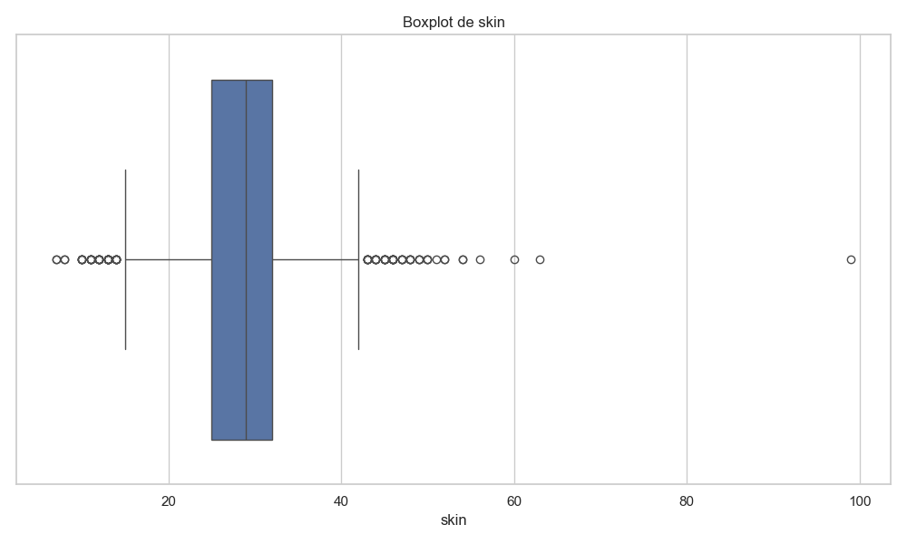

```
Boxplot de skin: permite identificar la mediana, los cuartiles y los valores atípicos de la variable.
```

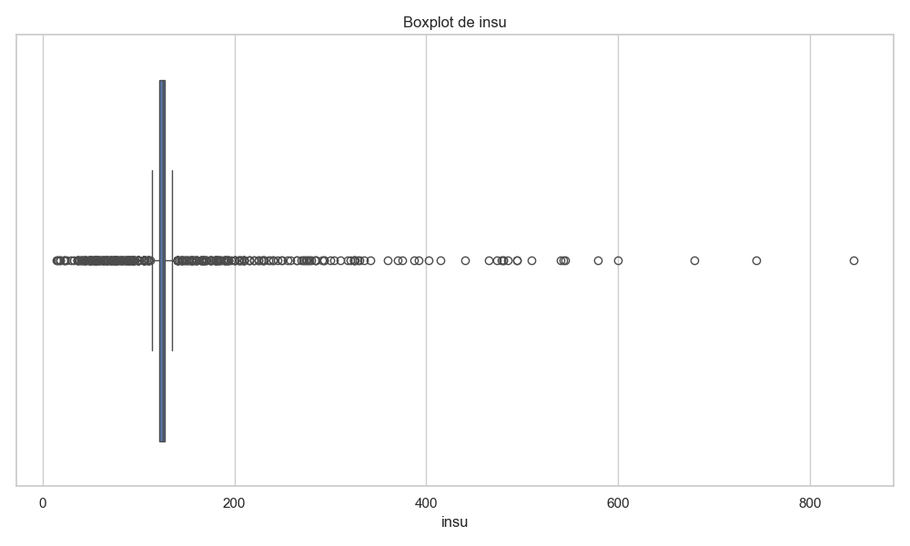

```
Boxplot de insu: permite identificar la mediana, los cuartiles y los valores atípicos de la variable.
```

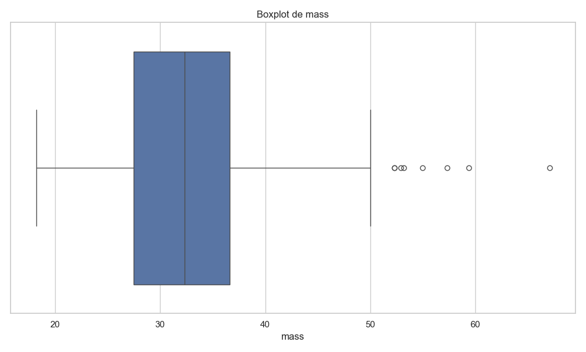

```
Boxplot de mass: permite identificar la mediana, los cuartiles y los valores atípicos de la variable.
```

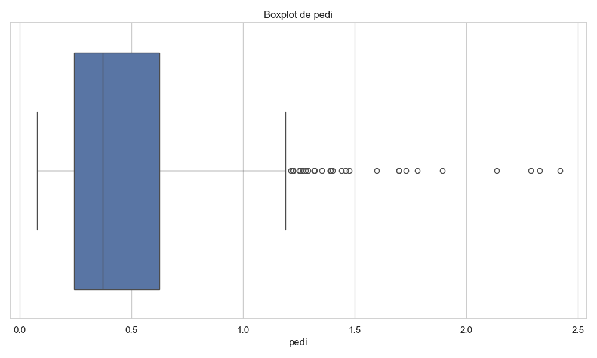

```
Boxplot de pedi: permite identificar la mediana, los cuartiles y los valores atípicos de la variable.
```

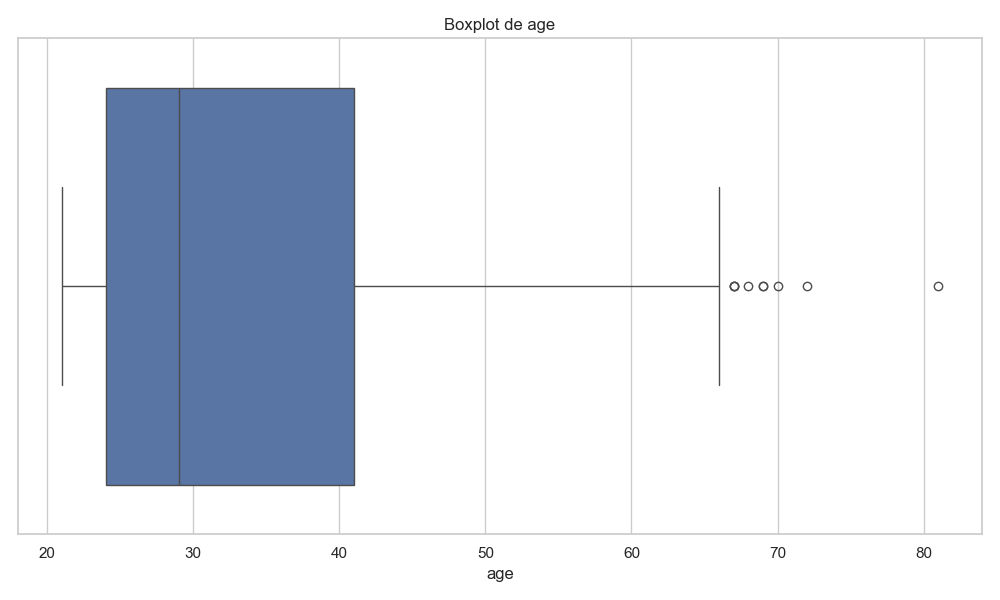

```
Boxplot de age: permite identificar la mediana, los cuartiles y los valores atípicos de la variable.
```

```python
# Mostrar boxplots de cada variable
for var in variables:
    display(Image(filename=f'../graficos/box_{var}.png'))
    print(f"Boxplot de {var}: permite identificar la mediana, los cuartiles y los valores atípicos de la variable.")
```

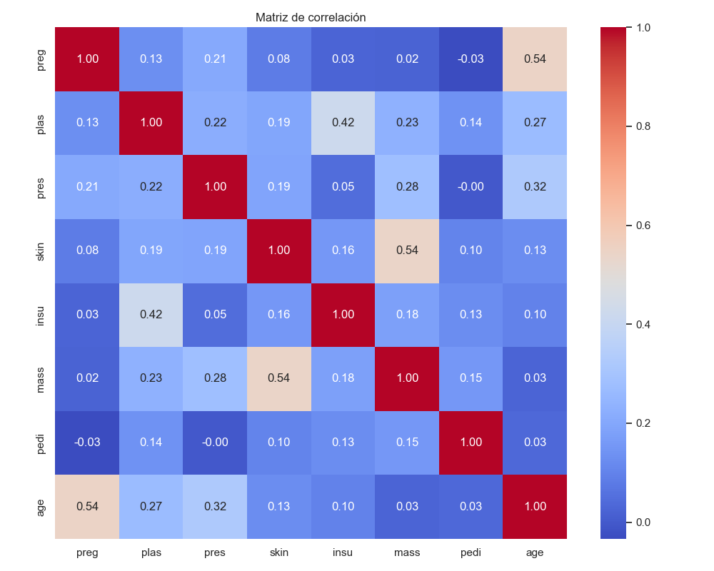

```
La matriz de correlación muestra la relación lineal entre las variables. Valores cercanos a 1 o -1 indican fuerte correlación positiva o negativa, respectivamente. Esto ayuda a identificar variables redundantes o altamente relacionadas.
```

```python
from IPython.display import Image, display

# Mostrar matriz de correlación
display(Image(filename='../graficos/matriz_correlacion.png'))
print("La matriz de correlación muestra la relación lineal entre las variables. Valores cercanos a 1 o -1 indican fuerte correlación positiva o negativa, respectivamente. Esto ayuda a identificar variables redundantes o altamente relacionadas.")
```

## 3. Entrenamiento y evaluación de modelos

En esta etapa se preparan los datos para el entrenamiento, se escalan las variables y se entrenan varios modelos de clasificación:

- Regresión logística
- Árbol de decisión
- Random Forest
- SVM

Se selecciona el mejor modelo según el F1-score y se guarda junto con el escalador.

```python
from sklearn.model_selection import train_test_split
from sklearn.preprocessing import StandardScaler
from sklearn.linear_model import LogisticRegression
from sklearn.tree import DecisionTreeClassifier
from sklearn.ensemble import RandomForestClassifier
from sklearn.svm import SVC
from sklearn.metrics import classification_report, confusion_matrix

# Cargar el dataset limpio
df = pd.read_csv('../data/dataset_limpio.csv')

# Preparar datos
X = df.drop('class', axis=1)
y = df['class'].map({'tested_negative': 0, 'tested_positive': 1})
X_train, X_test, y_train, y_test = train_test_split(X, y, test_size=0.2, random_state=42)

# Escalado de variables
scaler = StandardScaler()
X_train_scaled = scaler.fit_transform(X_train)
X_test_scaled = scaler.transform(X_test)

# Entrenamiento de modelos
modelos = {
    'LogisticRegression': LogisticRegression(max_iter=1000),
    'DecisionTree': DecisionTreeClassifier(),
    'RandomForest': RandomForestClassifier(n_estimators=100),
    'SVM': SVC(probability=True)
}

resultados = {}
for nombre, modelo in modelos.items():
    modelo.fit(X_train_scaled, y_train)
    y_pred = modelo.predict(X_test_scaled)
    print(f"\nEvaluación de: {nombre}")
    print(classification_report(y_test, y_pred, digits=4))
    reporte = classification_report(y_test, y_pred, output_dict=True)
    resultados[nombre] = reporte['weighted avg']['f1-score']

# Selección del mejor modelo
mejor = max(resultados, key=resultados.get)
print(f"\nMejor modelo: {mejor} (F1-score: {resultados[mejor]:.4f})")
```

```
Evaluación de: LogisticRegression
              precision    recall  f1-score   support

           0     0.7961    0.8283    0.8119        99
           1     0.6667    0.6182    0.6415        55

    accuracy                         0.7532       154
   macro avg     0.7314    0.7232    0.7267       154
weighted avg     0.7499    0.7532    0.7510       154


Evaluación de: DecisionTree
              precision    recall  f1-score   support

           0     0.7708    0.7475    0.7590        99
           1     0.5690    0.6000    0.5841        55

    accuracy                         0.6948       154
   macro avg     0.6699    0.6737    0.6715       154
weighted avg     0.6987    0.6948    0.6965       154


Evaluación de: RandomForest
              precision    recall  f1-score   support

           0     0.8298    0.7879    0.8083        99
           1     0.6500    0.7091    0.6783        55

    accuracy                         0.7597       154
   macro avg     0.7399    0.7485    0.7433       154
weighted avg     0.7656    0.7597    0.7619       154


Evaluación de: SVM
              precision    recall  f1-score   support

           0     0.7830    0.8384    0.8098        99
           1     0.6667    0.5818    0.6214        55

    accuracy                         0.7468       154
   macro avg     0.7248    0.7101    0.7156       154
weighted avg     0.7415    0.7468    0.7425       154


Mejor modelo: RandomForest (F1-score: 0.7619)
```

## 4. Interpretación de resultados

Para evaluar el desempeño del modelo seleccionado, se utilizan dos herramientas visuales clave:

- **Matriz de confusión:** muestra la cantidad de verdaderos positivos, verdaderos negativos, falsos positivos y falsos negativos.
- **Curva ROC:** ilustra la capacidad del modelo para distinguir entre clases, mostrando la relación entre la tasa de verdaderos positivos y la de falsos positivos.

A continuación se presentan ambos gráficos y su interpretación:

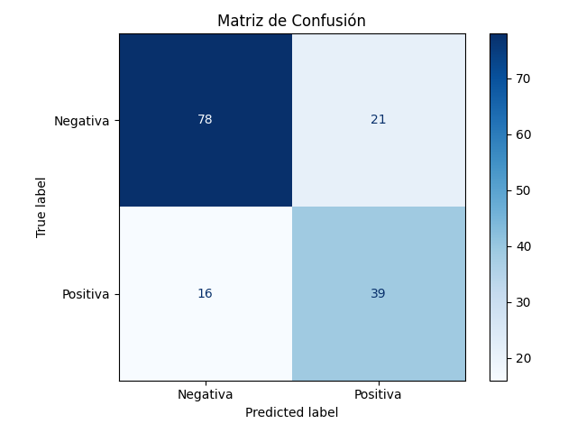

```
La matriz de confusión permite evaluar el desempeño del modelo en términos de aciertos y errores para cada clase. Un buen modelo tendrá altos valores en la diagonal principal.
```

```python
# Mostrar matriz de confusión
display(Image(filename='../graficos/matriz_confusion.png'))
print("La matriz de confusión permite evaluar el desempeño del modelo en términos de aciertos y errores para cada clase. Un buen modelo tendrá altos valores en la diagonal principal.")
```

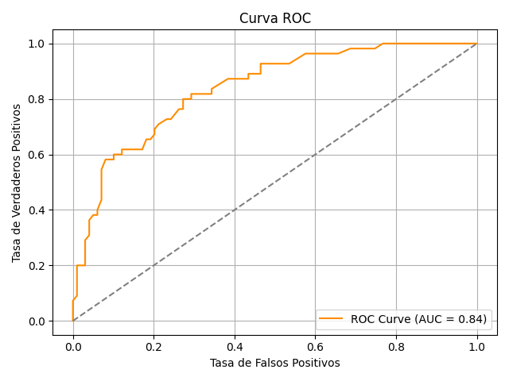

```
La curva ROC muestra la capacidad del modelo para distinguir entre clases. Un área bajo la curva (AUC) cercana a 1 indica un excelente desempeño.
El modelo tiene un 84% de probabilidad de asignar una mayor puntuación de predicción a un paciente positivo que a uno negativo al azar.
```

```python
# Mostrar curva ROC
display(Image(filename='../graficos/curva_roc.png'))
print("La curva ROC muestra la capacidad del modelo para distinguir entre clases. Un área bajo la curva (AUC) cercana a 1 indica un excelente desempeño.")
print("El modelo tiene un 84% de probabilidad de asignar una mayor puntuación de predicción a un paciente positivo que a uno negativo al azar.")
```

## Conclusión

Este análisis muestra cómo, a partir de un adecuado preprocesamiento y exploración de datos, es posible entrenar y evaluar modelos de machine learning para la detección de diabetes tipo 2. El uso de visualizaciones facilita la interpretación y validación de los resultados obtenidos.